# Dog Trainer Questionnaire vs Outcome (Fail, Success)

Marinara Marcato

# 1 Introduction

In order to objectively evaluate trainee guide dogs personality, their dog trainers filled out the standardised questionnaire Monash Canine Personality Questionnaire - Revised (MCPQ-R) after 10 weeks of training. This document shows the data analysis carried out to investigate the association between the ratings given by trainers and the dog’s training outcome. Statistical methods will be used to test the hypothesis that there is a relationship between personality ratings and training outcome (Success, Fail).

# 2 Data Exploration

Importing data and converting variables to adequate data types.

```
##  [1] "Code"                       "Timestamp"
##  [3] "Extraversion.Active"        "Extraversion.Energetic"
##  [5] "Extraversion.Excitable"     "Extraversion.Hyperactive"
##  [7] "Extraversion.Lively"        "Extraversion.Restless"
##  [9] "Extraversion.Comments"      "Motivation.Assertive"
## [11] "Motivation.Determined"      "Motivation.Independent"
## [13] "Motivation.Persevering"     "Motivation.Tenacious"
## [15] "Motivation.Comments"        "Training.Attentive"
## [17] "Training.Biddable"          "Training.Intelligent"
## [19] "Training.Obedient"          "Training.Reliable"
## [21] "Training.Trainable"         "Training.Comments"
## [23] "Amicability.Easy.going"     "Amicability.Friendly"
## [25] "Amicability.Non.aggressive" "Amicability.Relaxed"
## [27] "Amicability.Sociable"       "Amicability.Comments"
## [29] "Neuroticism.Fearful"        "Neuroticism.Nervous"
## [31] "Neuroticism.Submissive"     "Neuroticism.Timid"
## [33] "Neuroticism.Comments"       "DOA"
## [35] "Name"                       "PR.Sup"
## [37] "DOB"                        "Sex"
## [39] "Source"                     "Status"
## [41] "End.Date"                   "Breed"
## [43] "Coat.Colour"                "Duration"
## [45] "Outcome"                    "Label"
```

## 2.1 Demographics

The number of dogs in the Dog Trainer Questionnaire dataset. Selection criteria: dogs who successed training (assistance and guide dogs) and dogs withdrawn for behavioural reasons.

```
## Number of dogs: 89
```

```
## Training Outcome:
```

```
##
##    Fail Success
##      18      71
```

Analysing categorical demographic data: Sex, Breed. There was only one German Shepherd and two Golden Doodle dogs in the sample, their breeds were relabeled as “Other” for the data analysis.

```
##
##  F  M
## 44 45
```

```
## [1] "Original classes"
```

```
##
## GRxPoodle        GS        LR       LRx     LRxGR
##         2         1        37        16        33
```

```
## [1] "Processed classes"
```

```
##
## Other    LR LRxGR
##     3    37    49
```

Analysing age at arrival to the training centre and age at assessment when the questionnaire was completed:

```
## Age at Arrival: Mean 15.97 Standard Deviation 2.44
```

```
## Age at Assessment: Mean 18.34 Standard Deviation 2.6
```

```
## Duration at Assessment: Mean 2.37 Standard Deviation 0.7
```

```
##    Min. 1st Qu.  Median    Mean 3rd Qu.    Max.
##   2.857   9.429  10.429  10.316  11.286  21.286
```

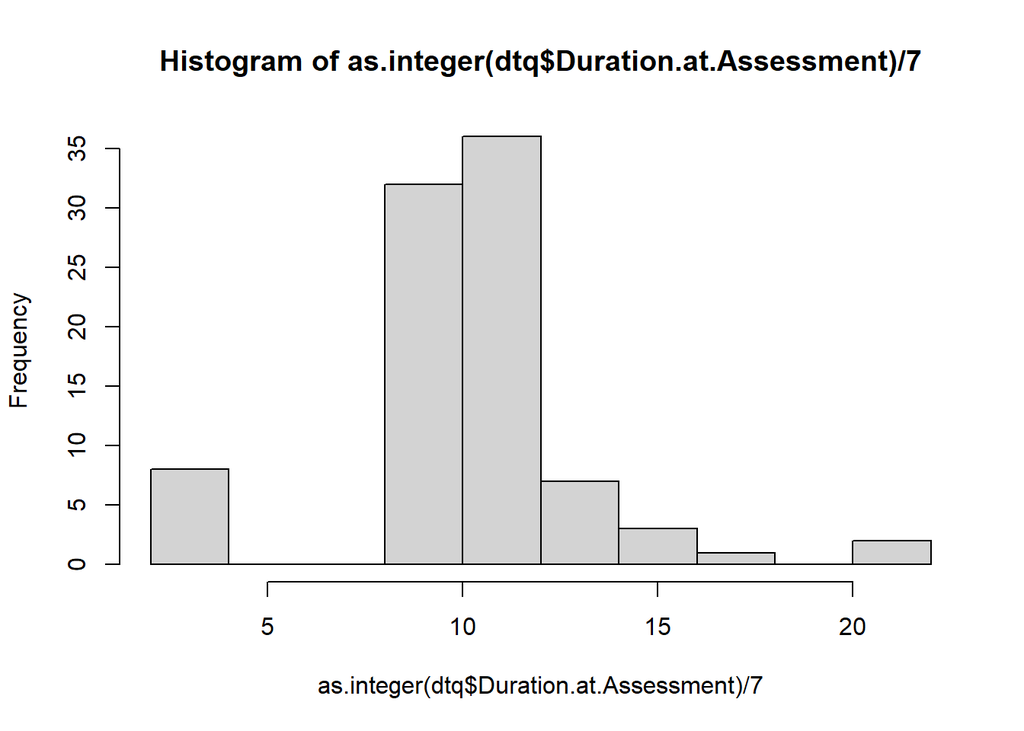

Calculate statistics of duration of training for the dogs that were withdrawn from training.

```
## [1] "Duration of Training in weeks"
```

```
##     Duration
##  Min.   : 1.143
##  1st Qu.:12.893
##  Median :14.571
##  Mean   :16.079
##  3rd Qu.:21.357
##  Max.   :31.143
```

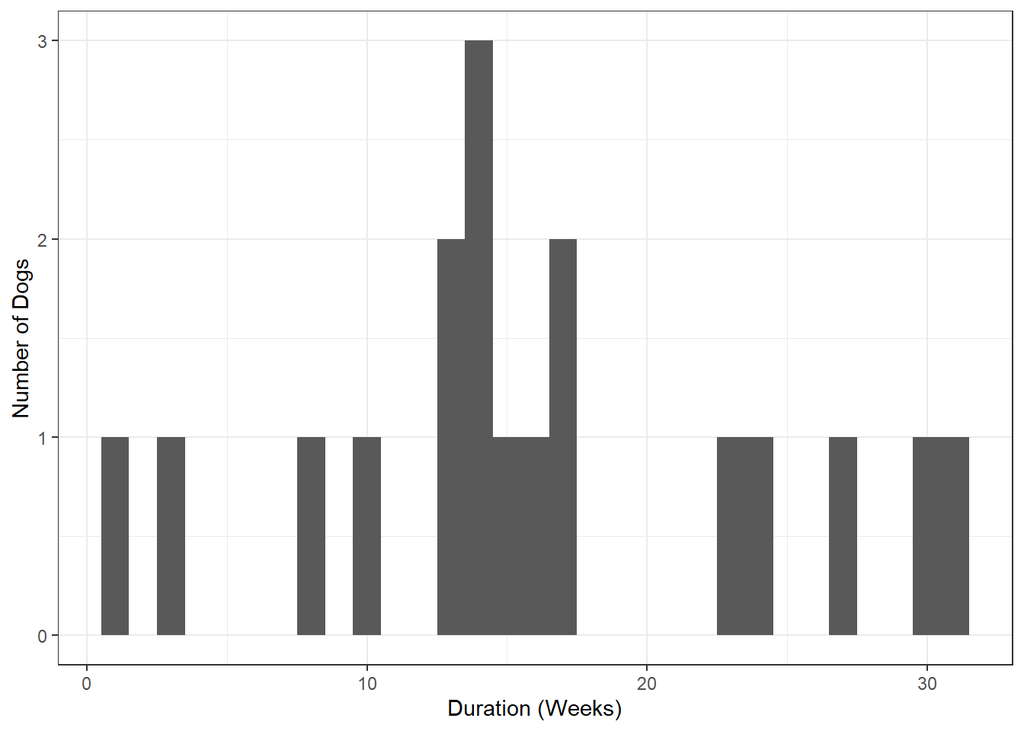

```
## Image saved at results/dtq/duration-histogram.png
```

## 2.2 Descriptive Statistics

The MCPQ-R contains 26 items which were scored by the Trainer in a scale from 1 to 6. The questionnaire data are kept as integers, rather than being converted to factors, so the information about the ordering is kept. The descriptive statistics of the questionnaire data shown below are saved as a csv.

```
##  [1] "Extraversion.Active"        "Extraversion.Energetic"
##  [3] "Extraversion.Excitable"     "Extraversion.Hyperactive"
##  [5] "Extraversion.Lively"        "Extraversion.Restless"
##  [7] "Motivation.Assertive"       "Motivation.Determined"
##  [9] "Motivation.Independent"     "Motivation.Persevering"
## [11] "Motivation.Tenacious"       "Training.Attentive"
## [13] "Training.Biddable"          "Training.Intelligent"
## [15] "Training.Obedient"          "Training.Reliable"
## [17] "Training.Trainable"         "Amicability.Easy.going"
## [19] "Amicability.Friendly"       "Amicability.Non.aggressive"
## [21] "Amicability.Relaxed"        "Amicability.Sociable"
## [23] "Neuroticism.Fearful"        "Neuroticism.Nervous"
## [25] "Neuroticism.Submissive"     "Neuroticism.Timid"
## [27] "Sex"                        "Breed"
## [29] "Outcome"
```

```
## Dimension of the dataset including the dependent variable:  89 29
```

```
##                            Min. X1st.Qu. Median     Mean X3rd.Qu. Max.
## Extraversion.Active           1        3      4 3.808989        5    6
## Extraversion.Energetic        1        3      4 3.764045        5    6
## Extraversion.Excitable        1        3      4 3.752809        5    6
## Extraversion.Hyperactive      1        2      3 2.719101        3    6
## Extraversion.Lively           1        3      4 3.617978        4    6
## Extraversion.Restless         1        2      3 3.067416        4    6
## Motivation.Assertive          1        3      3 3.235955        4    6
## Motivation.Determined         1        3      4 3.550562        4    5
## Motivation.Independent        1        2      3 3.247191        4    5
## Motivation.Persevering        1        3      3 3.404494        4    5
## Motivation.Tenacious          1        3      3 3.224719        4    6
## Training.Attentive            1        3      4 3.910112        5    6
## Training.Biddable             2        3      4 3.853933        5    6
## Training.Intelligent          2        4      5 4.494382        5    6
## Training.Obedient             2        3      4 4.067416        5    6
## Training.Reliable             2        3      4 3.797753        5    6
## Training.Trainable            1        4      5 4.370787        5    6
## Amicability.Easy.going        1        3      4 3.685393        5    6
## Amicability.Friendly          1        4      5 4.932584        6    6
## Amicability.Non.aggressive    1        5      6 5.112360        6    6
## Amicability.Relaxed           1        3      4 3.651685        5    6
## Amicability.Sociable          1        4      5 4.674157        5    6
## Neuroticism.Fearful           1        2      2 2.370787        3    6
## Neuroticism.Nervous           1        1      2 2.382022        3    6
## Neuroticism.Submissive        1        2      2 2.617978        3    5
## Neuroticism.Timid             1        2      2 2.505618        3    6
```

```
## dataframe saved to  results/dtq/descriptive-statistics.csv
```

## 2.3 Feature Selection

### 2.3.1 Criteria 1 and 2: Univariate Logistic Regression

Logistic regression was used to investigate whether there was a statistically significant difference between the behaviours reported by Dot Trainers and the Training Outcome of the dogs. MCPQ-R Correlation with Training Outcome.

Breeds (p = 0.82 and p = 0.40) and Sex (p = 0.32) were not significantly associated with training outcome.

```
## $Breed
##
## Call:  glm(formula = Outcome ~ x, family = binomial(link = logit), data = data)
##
## Coefficients:
## (Intercept)          xLR       xLRxGR
##     -0.6931      -0.3001      -1.0986
##
## Degrees of Freedom: 88 Total (i.e. Null);  86 Residual
## Null Deviance:       89.62
## Residual Deviance: 87.19     AIC: 93.19
```

```
## Difference between Other and LR:      0.8145546   -> not significant
```

```
## Difference between Other and LRxGR:   0.3947796   -> not significant
```

```
##                        estimate_1    p_value_1
## Motivation.Persevering -0.5906303 0.0479482121
## Training.Attentive     -0.5583776 0.0262134018
## Training.Obedient      -0.6274951 0.0194046735
## Training.Reliable      -1.0922284 0.0005663551
## Training.Trainable     -1.0920737 0.0001864415
## Amicability.Easy.going -0.8399518 0.0017176375
## Amicability.Friendly   -0.7628613 0.0036304533
## Amicability.Relaxed    -0.7331794 0.0020678303
## Amicability.Sociable   -0.6424009 0.0100094279
## Neuroticism.Fearful     0.7427824 0.0011024520
## Neuroticism.Nervous     0.6455290 0.0024115622
## Neuroticism.Submissive  0.6440879 0.0255504521
## Neuroticism.Timid       0.7064604 0.0060106266
```

```
## Difference between Sex:   0.3192585   -> not significant
```

```
## dataframe saved to  results/dtq/univariate-logistic-regression.csv
```

Converting logistic regression result to odds ratio and confidence intervals.

```
## $Extraversion.Active
##                  2.5 %   97.5 %
## (Intercept) -2.4849798 1.334054
## x           -0.7342562 0.267567
```

```
##      2.5 % 97.5 %
```

```
## dataframe saved to  results/dtq/lr-or-ci.csv
```

Analysing p-values and deviance. Analysing deviance of full model compared to the null model. Reduction in deviance must be significant (chi-squared test) for the model to be considered a good fit.

```
## Number of features whose univariate models resulted in a significant difference in pvalue:  13
```

```
## Number of features whose univariate models resulted in a significant difference in deviance:  27
```

```
## [1] "All features with level of significance < 0.05 using Univariate Logistic Regression p-value test"
```

```
## Full Feature Set with p<0.05 and reduction in deviance    89 14
```

```
##  [1] "Motivation.Persevering" "Training.Attentive"     "Training.Obedient"
##  [4] "Training.Reliable"      "Training.Trainable"     "Amicability.Easy.going"
##  [7] "Amicability.Friendly"   "Amicability.Relaxed"    "Amicability.Sociable"
## [10] "Neuroticism.Fearful"    "Neuroticism.Nervous"    "Neuroticism.Submissive"
## [13] "Neuroticism.Timid"      "Outcome"
```

### 2.3.2 Criterion 3: Correlation

Removing features with more than 0.75 correlation

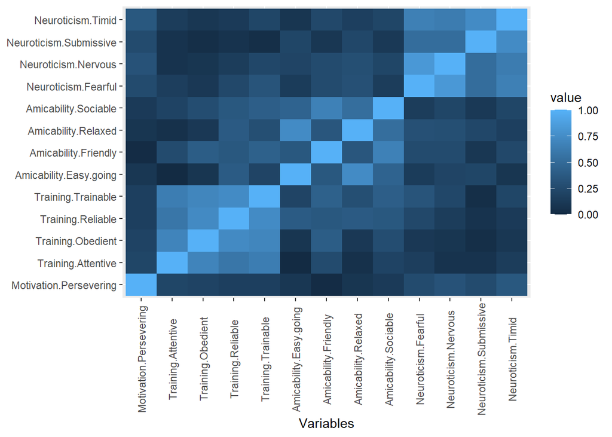

```
## Image saved at results/dtq/correlation.png
```

```
## Highly correlated variable to be removed Neuroticism.Fearful
```

[output not shown]

```
## Reduced Feature Set with p<0.05 and <75% correlated   89 13
```

## 2.4 Visualization

Plotting features selected considering univariate logistic regression pvalue results.

```
## Image saved at results/dtq/Motivation-Persevering.png
```

```
## Image saved at results/dtq/Training-Attentive.png
```

```
## Image saved at results/dtq/Training-Obedient.png
```

```
## Image saved at results/dtq/Training-Reliable.png
```

```
## Image saved at results/dtq/Training-Trainable.png
```

```
## Image saved at results/dtq/Amicability-Easy-going.png
```

```
## Image saved at results/dtq/Amicability-Friendly.png
```

```
## Image saved at results/dtq/Amicability-Relaxed.png
```

```
## Image saved at results/dtq/Amicability-Sociable.png
```

```
## Image saved at results/dtq/Neuroticism-Nervous.png
```

```
## Image saved at results/dtq/Neuroticism-Submissive.png
```

```
## Image saved at results/dtq/Neuroticism-Timid.png
```

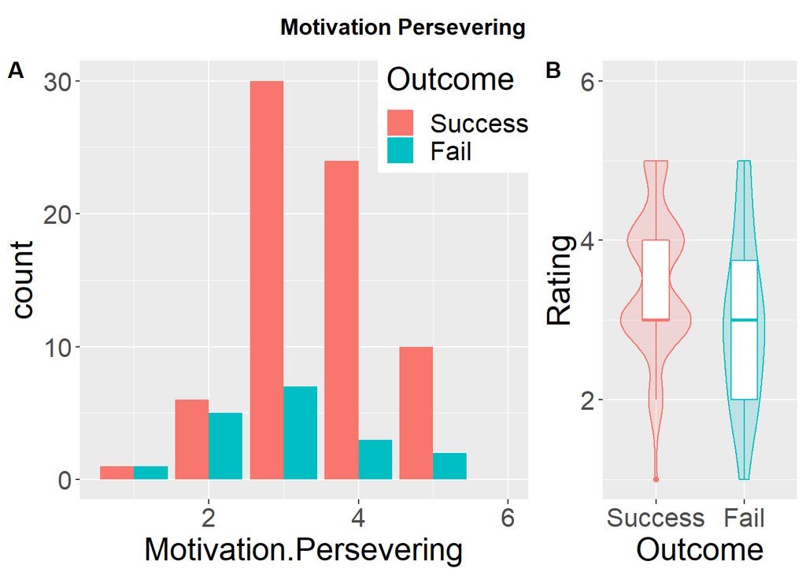

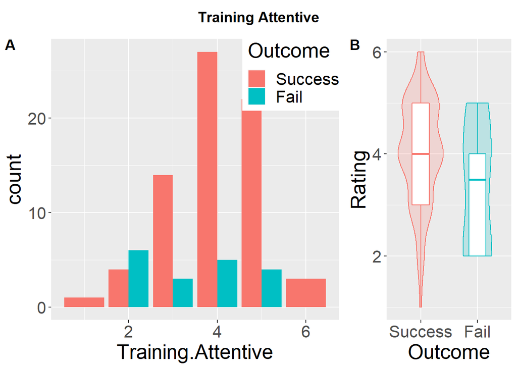

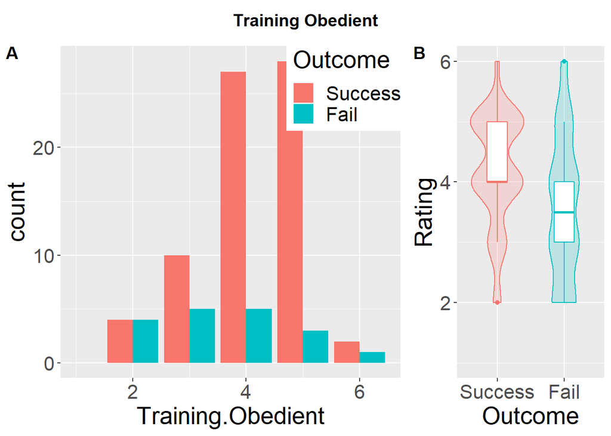

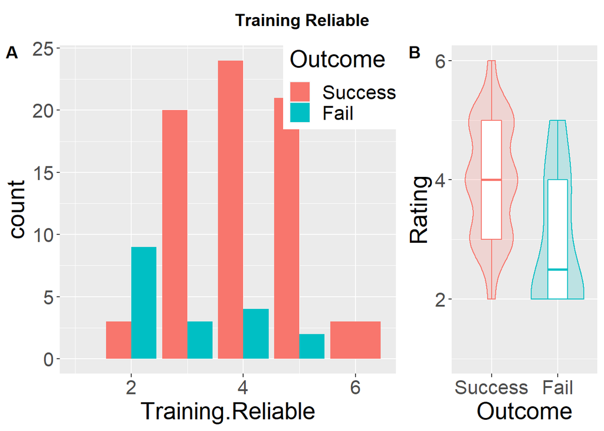

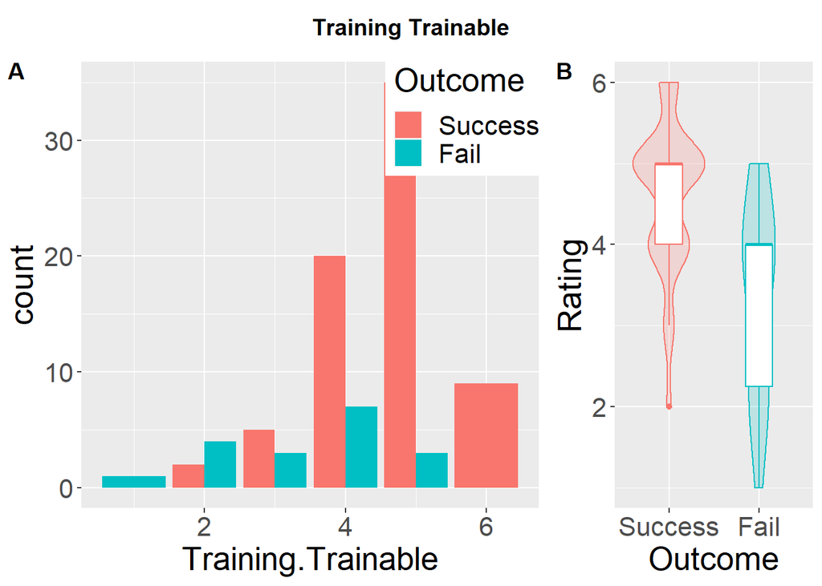

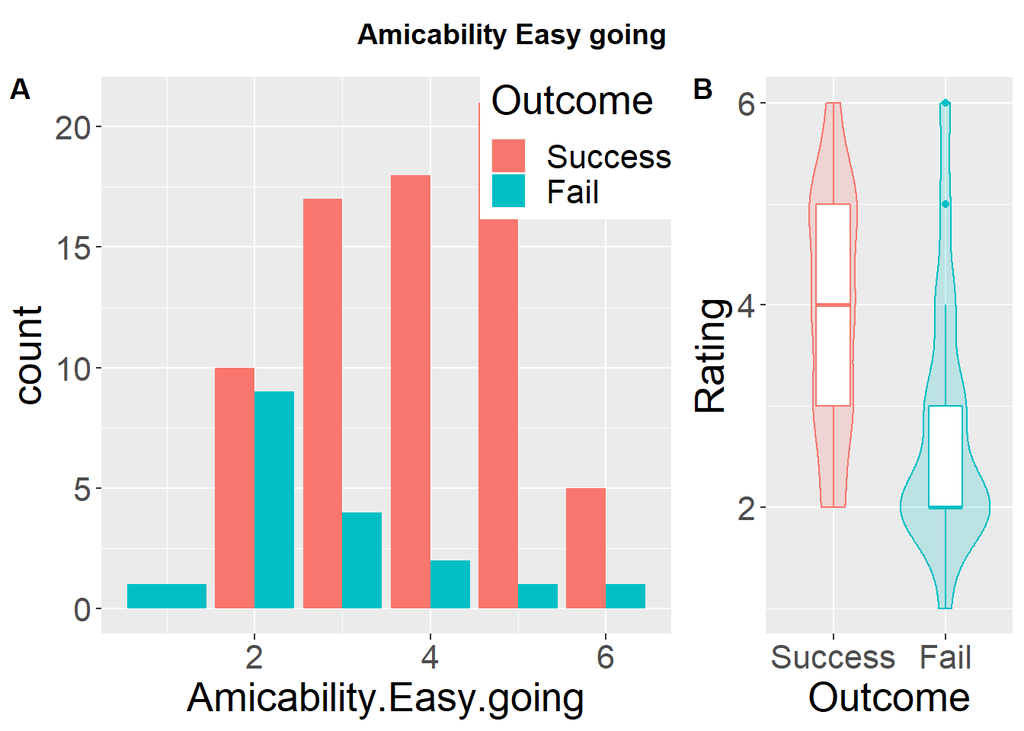

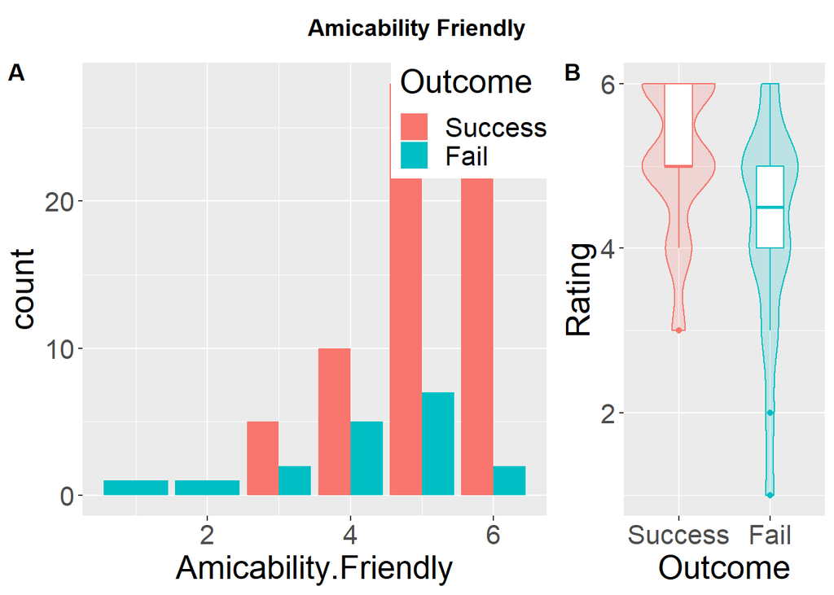

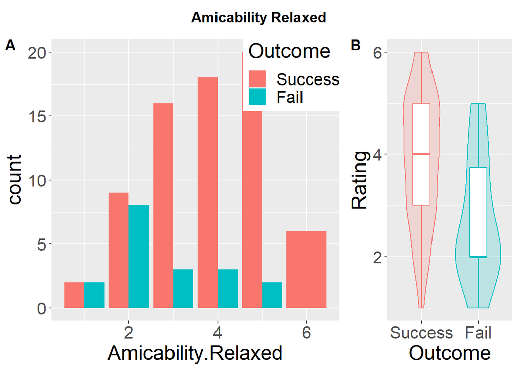

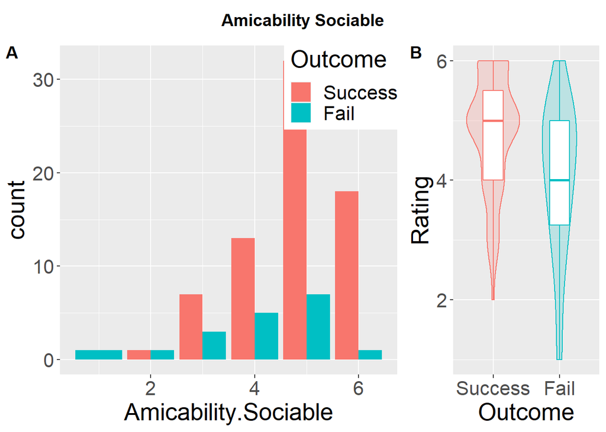

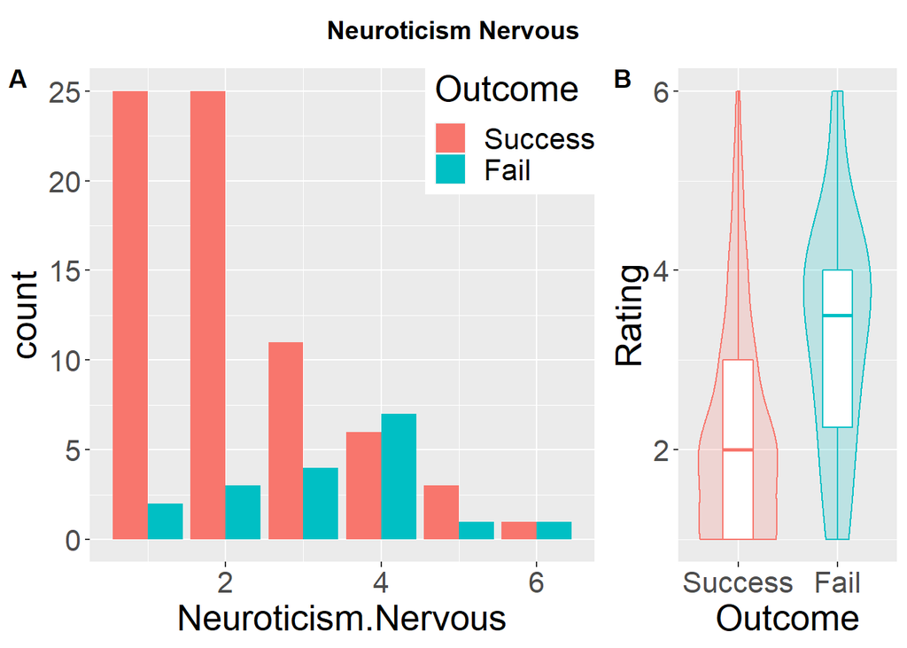

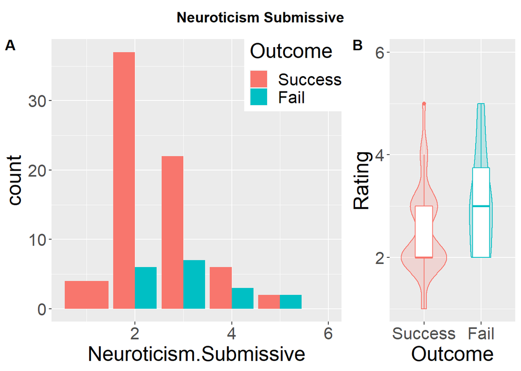

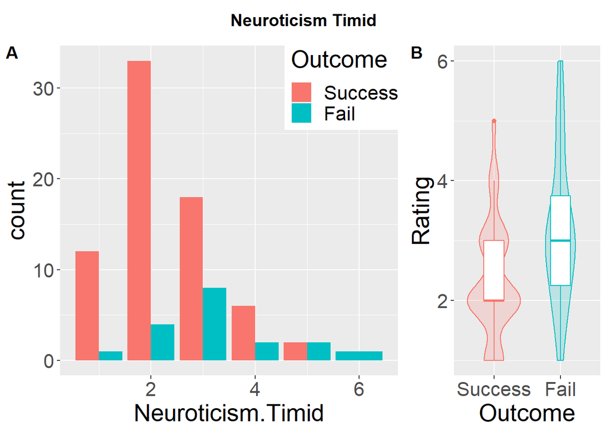

# 3 Multivariate Model

## 3.1 Multicollinearity

The Variance Inflation Factor (VIF) was calculate to assess multicollinearity. VIF = 1 no correlation, 5 < VIF < 10 moderate correlation, VIF > 10 high multicollinearity. VIF larger than 5 or 10 is large and indicate a high level of multicollinearity and should be further processed.

```
##
## Call:
## glm(formula = Outcome ~ ., family = binomial(link = logit), data = data_reduced)
##
## Deviance Residuals:
##     Min       1Q   Median       3Q      Max
## -2.5018  -0.4857  -0.2586  -0.1121   2.3839
##
## Coefficients:
##                        Estimate Std. Error z value Pr(>|z|)
## (Intercept)             7.00786    3.66556   1.912   0.0559 .
## Motivation.Persevering -0.63622    0.46388  -1.372   0.1702
## Training.Attentive      0.03848    0.58143   0.066   0.9472
## Training.Obedient       0.65392    0.67933   0.963   0.3357
## Training.Reliable      -0.28879    0.67809  -0.426   0.6702
## Training.Trainable     -1.33172    0.68606  -1.941   0.0522 .
## Amicability.Easy.going -0.73644    0.46548  -1.582   0.1136
## Amicability.Friendly   -0.68483    0.49323  -1.388   0.1650
## Amicability.Relaxed     0.02115    0.44909   0.047   0.9624
## Amicability.Sociable    0.40039    0.53310   0.751   0.4526
## Neuroticism.Nervous     0.20343    0.39108   0.520   0.6029
## Neuroticism.Submissive  0.30884    0.62900   0.491   0.6234
## Neuroticism.Timid      -0.01002    0.61974  -0.016   0.9871
## ---
## Signif. codes:  0 '***' 0.001 '**' 0.01 '*' 0.05 '.' 0.1 ' ' 1
##
## (Dispersion parameter for binomial family taken to be 1)
##
##     Null deviance: 89.623  on 88  degrees of freedom
## Residual deviance: 54.282  on 76  degrees of freedom
## AIC: 80.282
##
## Number of Fisher Scoring iterations: 6
```

```
## dataframe saved to  results/dtq/multicollinearity.csv
```

```
## Motivation.Persevering     Training.Attentive      Training.Obedient
##               1.573781               3.294977               4.001891
##      Training.Reliable     Training.Trainable Amicability.Easy.going
##               3.546976               3.644313               2.278760
##   Amicability.Friendly    Amicability.Relaxed   Amicability.Sociable
##               2.300042               2.517096               2.724500
##    Neuroticism.Nervous Neuroticism.Submissive      Neuroticism.Timid
##               2.261575               2.871045               3.386554
```

```
## dataframe saved to  results/dtq/VIF.csv
```

## 3.2 Preprocessing: Normalization + PCA

Only variables that had a pvalue < 0.05 in univariate logistic regression analysis. They were normalized and KNN imputation was used to replace missing values. Principal Component Analysis (PCA) was used to combine the original questionnaire items to derive features that capture the variance dataset and are uncorrelated (orthogonal). The Principal Components that captured up to 95% of the variance of the original questionnaire data were used as predictors to estimate Outcome using Logistic Regression.

## 3.3 Recursive Feature Elimination (RFE) + Multivariate Logistic Regression (LR)

Backwards Feature Selection is used to eliminate the least predictive Principal Components. It estimates the importance of each principal component by evaluating the difference in performance caused by the removal of individual components. Leave One Subject Out Cross Validation divides these datasets into train sets for modelling and test sets for estimating performance. The AUC-ROC results achieved on the test sets by each of the models trained are considered when choosing which features to keep and remove in order to derive an optimal model. This methodology was implemented in R using [rfe](https://search.r-project.org/CRAN/refmans/caret/html/rfe.html) (recursive feature elimination) function with ROC and [rfeControl](https://search.r-project.org/CRAN/refmans/caret/html/rfeControl.html) function with LOOCV in caret.

[Example with RF](https://towardsdatascience.com/effective-feature-selection-recursive-feature-elimination-using-r-148ff998e4f7), [ROC as metric](https://stackoverflow.com/questions/18242692/r-package-caret-rfe-function-how-to-customize-metric-to-use-auc).

```
## predicting second class: Fail Success
```

```
##
## Recursive feature selection
##
## Outer resampling method: Cross-Validated (89 fold)
##
## Resampling performance over subset size:
##
##  Variables AUC Precision Recall F AUCSD PrecisionSD RecallSD FSD Num_Resamples
##          1 NaN    0.7500 0.3333 1    NA      0.4629   0.4851   0            89
##          2 NaN    0.6667 0.4444 1    NA      0.4924   0.5113   0            89
##          3 NaN    0.6364 0.3889 1    NA      0.5045   0.5016   0            89
##          4 NaN    0.5833 0.3889 1    NA      0.5149   0.5016   0            89
##          5 NaN    0.5714 0.4444 1    NA      0.5136   0.5113   0            89
##          6 NaN    0.5333 0.4444 1    NA      0.5164   0.5113   0            89
##          7 NaN    0.5333 0.4444 1    NA      0.5164   0.5113   0            89
##          8 NaN    0.5333 0.4444 1    NA      0.5164   0.5113   0            89
##          9 NaN    0.5333 0.4444 1    NA      0.5164   0.5113   0            89
##  Selected
##         *
##
##
##
##
##
##
##
##
##
## The top 1 variables (out of 1):
##    PC1
```

```
##
## Call:
## glm(formula = Class ~ ., family = "binomial", data = tmp)
##
## Deviance Residuals:
##     Min       1Q   Median       3Q      Max
## -2.3153   0.1621   0.3301   0.5692   2.2228
##
## Coefficients:
##             Estimate Std. Error z value Pr(>|z|)
## (Intercept)   1.8632     0.3687   5.054 4.32e-07 ***
## PC1          -0.7738     0.1957  -3.953 7.71e-05 ***
## ---
## Signif. codes:  0 '***' 0.001 '**' 0.01 '*' 0.05 '.' 0.1 ' ' 1
##
## (Dispersion parameter for binomial family taken to be 1)
##
##     Null deviance: 89.623  on 88  degrees of freedom
## Residual deviance: 63.579  on 87  degrees of freedom
## AIC: 67.579
##
## Number of Fisher Scoring iterations: 5
```

Model fitness with deviance analysis.

```
##
## deviance difference:  26.04418
```

```
##
## df difference:  1
```

```
##
## level of significance:  3.33694e-07
```

```
##
## the model is a good fit:  TRUE
```

Performance metrics ROC and PR curves.

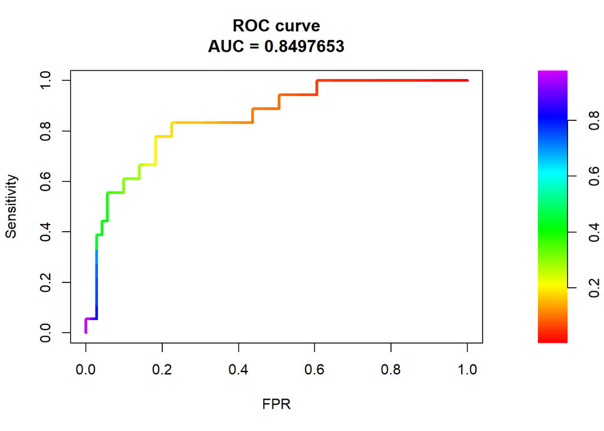

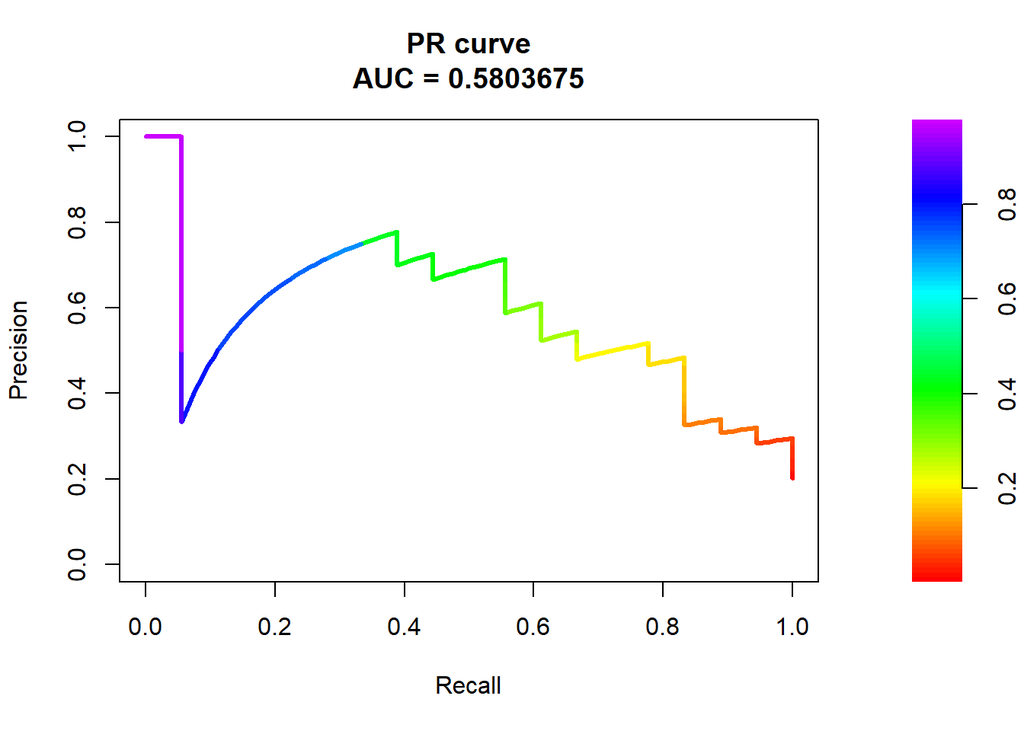

```
## Confusion Matrix and Statistics
##
##           Reference
## Prediction Fail Success
##    Fail       6       2
##    Success   12      69
##
##                Accuracy : 0.8427
##                  95% CI : (0.7502, 0.9112)
##     No Information Rate : 0.7978
##     P-Value [Acc > NIR] : 0.17873
##
##                   Kappa : 0.385
##
##  Mcnemar's Test P-Value : 0.01616
##
##             Sensitivity : 0.33333
##             Specificity : 0.97183
##          Pos Pred Value : 0.75000
##          Neg Pred Value : 0.85185
##              Prevalence : 0.20225
##          Detection Rate : 0.06742
##    Detection Prevalence : 0.08989
##       Balanced Accuracy : 0.65258
##
##        'Positive' Class : Fail
##
```

```
##          Accuracy  ROC   PR Precision Recall Sensitivity Specificity    F1
## Accuracy    0.843 0.85 0.58      0.75  0.333       0.333       0.972 0.462
##          Balanced.Accuracy
## Accuracy             0.653
```

```
## [1] "Probability predicted by the LR using PRQ data vs true Outcome"
```

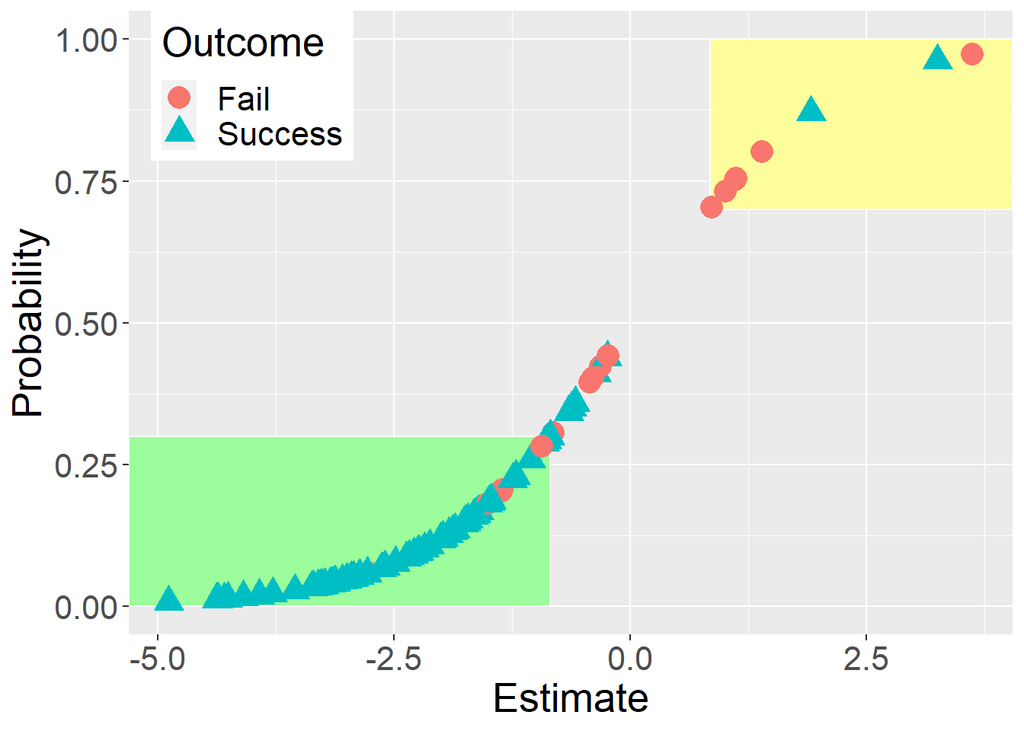

```
## Image saved at results/dtq/logit-outcome.png
```

```
## [1] "Probability predicted by the LR using PRQ data vs true Status"
```

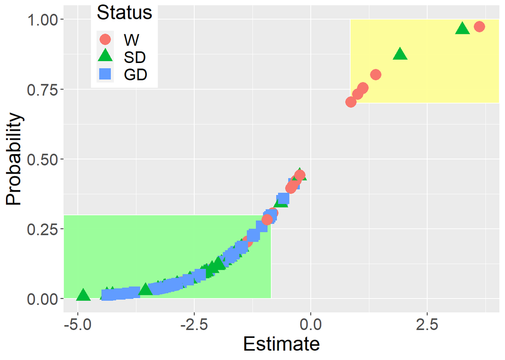

```
## Image saved at results/dtq/logit-status.png
```

```
## [1] "Estimate and Probabilities per training outcome status"
```

```
## # A tibble: 3 × 2
##   Status   Mean
##   <fct>   <dbl>
## 1 W      -0.299
## 2 SD     -2.07
## 3 GD     -2.37
```

```
## # A tibble: 3 × 2
##   Status  Mean
##   <fct>  <dbl>
## 1 W      0.434
## 2 SD     0.168
## 3 GD     0.125
```

```
## Predicted probability < 0.3  -> Green flag
```

```
## [1] "Dogs flagged green are likely to SUCCEED, true outcome count and status proportion:"
```

```
##
##    Fail Success
##       7      64
```

```
##
##          W         SD         GD
## 0.09859155 0.35211268 0.54929577
```

```
## Predicted probability > 0.7 -> Yellow flag
```

```
## [1] "Dogs flagged yellow are likely to FAIL, true outcome count and status proportion:"
```

```
##
##    Fail Success
##       6       2
```

```
##
##    W   SD   GD
## 0.75 0.25 0.00
```

```
## 0.3  < Predicted probability < 0.7 -> no flags
```

```
##
##  W SD GD
##  5  2  3
```

## 3.4 Interpretation

The best Logistic Regression model is used to investigate the effect of the principal components on the training outcome. The estimates were exponentiated to get the Odds Ratio (OR). The 95% Confident Interval (CI) of the ORs was also calculated. RFE chose 1 principal components, PC1. The OR for PC1 is 2.16, this means that the probability of withdrawal increases by (2.16-1 = 1.16) 116% for every unit increase of PC1. We are 95% confident that a unit increase in PC1 results in a 54 to 236% (1.54-1 = 0.54, 3.36-1 = 2.36) more odds of being withdrawn from training.

```
## [1] "Results from the model created with the reduced feature set"
```

```
##               Estimate Std. Error   z value     Pr(>|z|)        OR     2.5 %
## (Intercept)  1.8631981  0.3686527  5.054075 4.324819e-07 6.4443135 3.3348178
## PC1         -0.7737642  0.1957285 -3.953252 7.709631e-05 0.4612735 0.2968262
##                97.5 %
## (Intercept) 14.432755
## PC1          0.648145
```

```
## dataframe saved to  results/dtq/rfe-lr.csv
```

## 3.5 Feature Importance

### 3.5.1 Explained Variance

```
## [1] "Explained Variance per Principal Component (Scree Plot)"
```

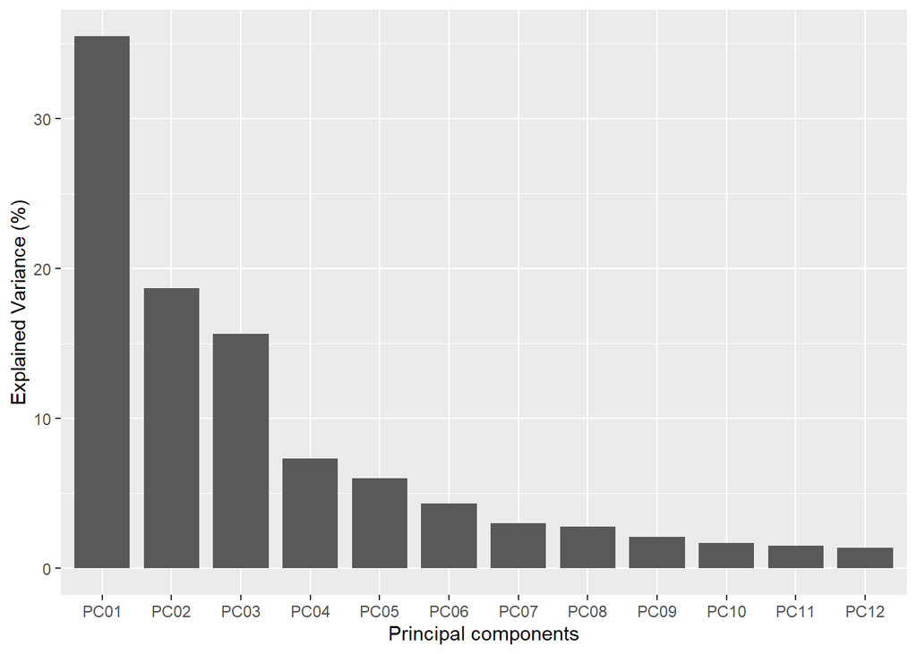

### 3.5.2 Coefficient Loadings

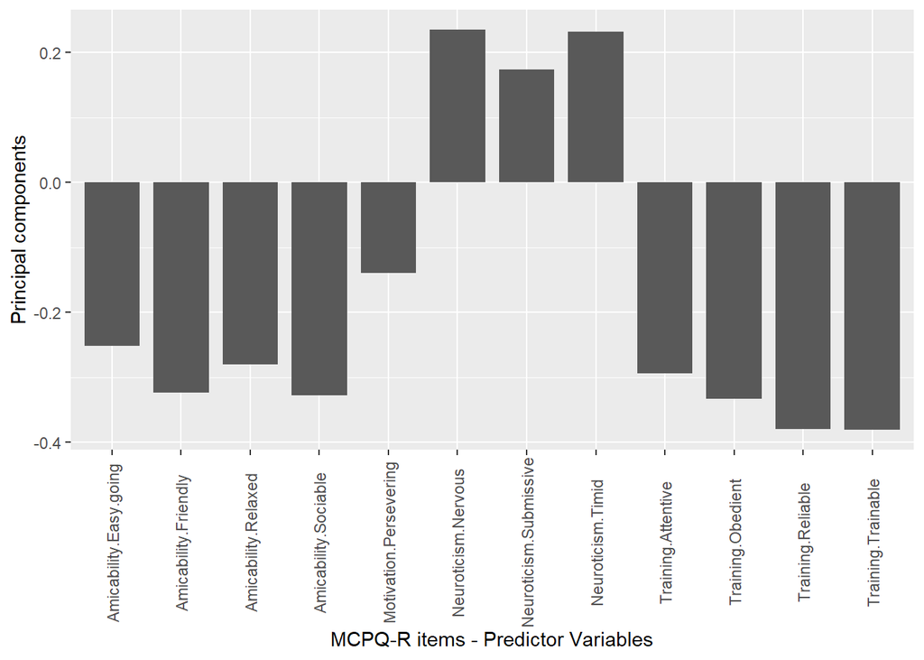

```
## Image saved at results/dtq/pc-loading.png
```

```
## dataframe saved to  results/dtq/pc-loading.csv
```

```
##                     terms      value
## 1      Training.Trainable -0.3811001
## 2       Training.Reliable -0.3800595
## 3       Training.Obedient -0.3335403
## 4    Amicability.Sociable -0.3273747
## 5    Amicability.Friendly -0.3236865
## 6      Training.Attentive -0.2937333
## 7     Amicability.Relaxed -0.2806934
## 8  Amicability.Easy.going -0.2518185
## 9     Neuroticism.Nervous  0.2350126
## 10      Neuroticism.Timid  0.2318816
## 11 Neuroticism.Submissive  0.1738773
## 12 Motivation.Persevering -0.1393101
```

# 4 Conclusion

Completing this questionnaire during training (Week 10) would allow assistance dog training organisations to understand which dog are more suitable and allow them to make informed decisions when analysing which dogs to keep for training considering the results of this objective assessment.